# Past Pandemics

# Research question

- Estimate excess mortality for pandemics in 1890, 1918 and 2020 per district, age groups and sex
- Comparing of spatial pattern between the pandemics
- Investigate the determinants of spread in the context of different co-factors ( Urbanization, GIP per capita, etc-)

# Data

- Collected and digitalized from Kaspar Staub’s team
- Russian flu: 1879 - 1895
- Spanish fl: 1908 - 1925
- Covid19 : 2020

## Population

- Modern data population for all districts and all age groups and sex available
- Census 1888 and 1910 population data for all districts and age groups and sex, but 1900 and 1920 are not collect -> might a problem
- Census 1880, 1888, 1900, 1910, 1920 census data for all districts  
  Estimation:
- Interpolation for total and each districts (census 1880, 1888, 1900, 1910, 1920)
- Calculation of age distribution for 1888 and 1910
- Take age distribution of 1888 to interpolate population between 1880 to 1900 and age distribution from 1910 to interpolate population between 1900 and 1920
- Maybe a student from Kaspar will also collect detailed census data from 1900 and 1920, would be a bit more precise then

## Maps

- All districts are harmonised so that 1890, 1918 and 2020 have the same districts.
- Many districts from 1879 - 1920 have been combined so that they are the same as 2014-2020.
- Schauffhausen is only one district, as death data is only available for Schaffhausen as a whole.
- In Solothurn, the districts are merged as in 1876 - 1920.
- New shapefiles created via QGIS to have one map for all years (to make them comparable).

# Preliminary Methods

- Estimation of expected mortality using Poisson GLM for total, sex and age groups
- Only yearly data available, therefor no seasonal effects etc can be taken into account
- Excess mortality is based on the trend in the previous 4 years (sind for 1890 only 4 years available)
- Pandemic years 1890, 1918 and 2020 are excluded to estimate expected values
- Bootstrapping to address the uncertainty in observed death counts and to provide a prediction interval (PI) for the predicted mortality(resampled N = 1000)
- Excess mortality is shown relatively in percentage (excess mortality = (pandemic year -baseline mortality)/baseline mortality
- To compare the districts the percentages are normalised, meaning for each year the quantiles are estimated, to see for example if same district have high excess mortality between the pandemics
- To find pattern and clusters: Moran’s I statistics ( LISA: Local Indicators of Spatial Association) were user mapping statistically significant local clusters.

# Preliminary Results

## Total

### Relative yearly numbers of excess deaths

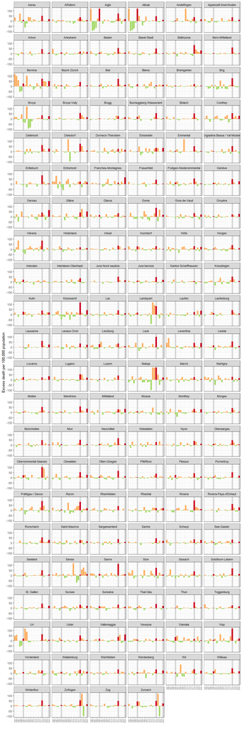

### Maps

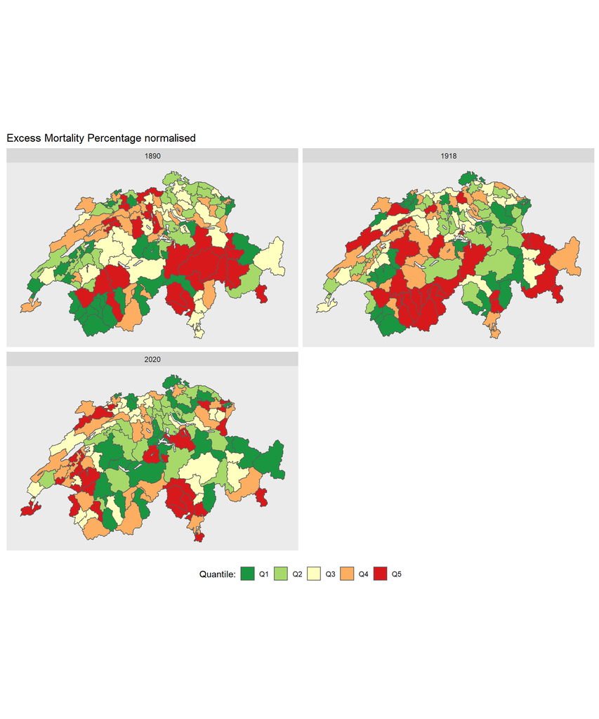

### LISA (Local Indicators of Spatial Association)

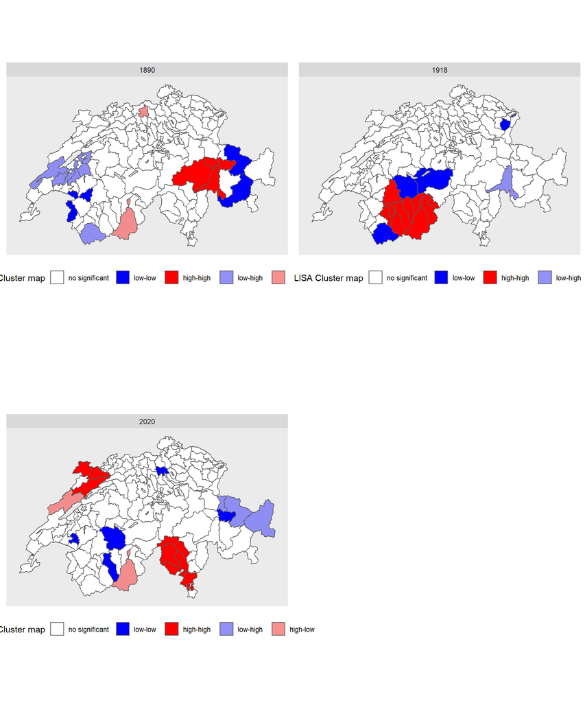

## Sex

### Maps

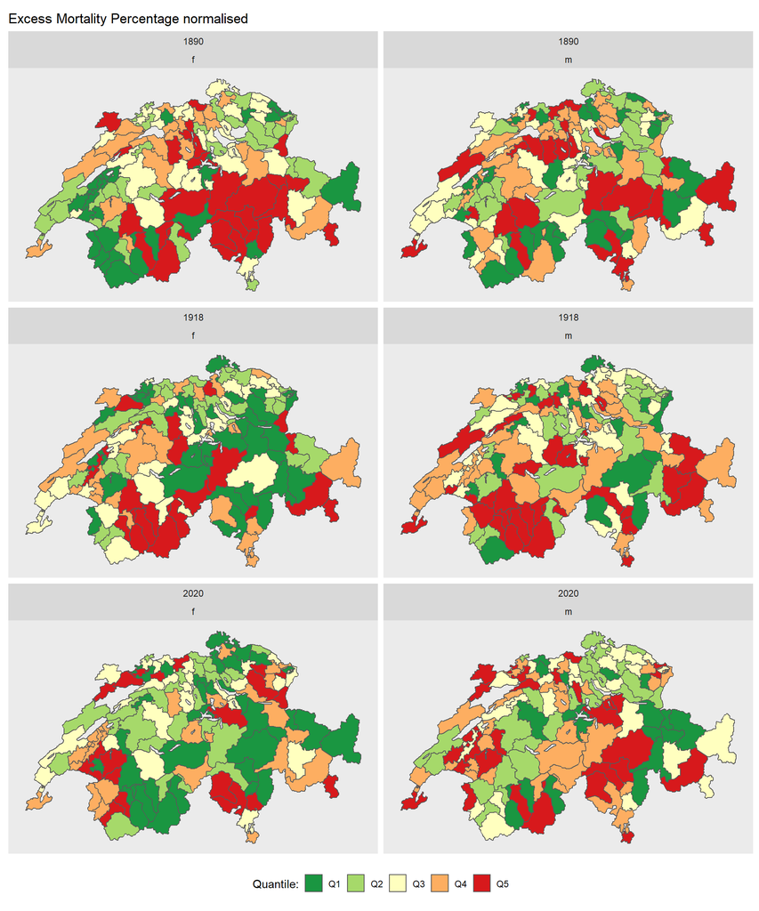

### LISA (Local Indicators of Spatial Association)

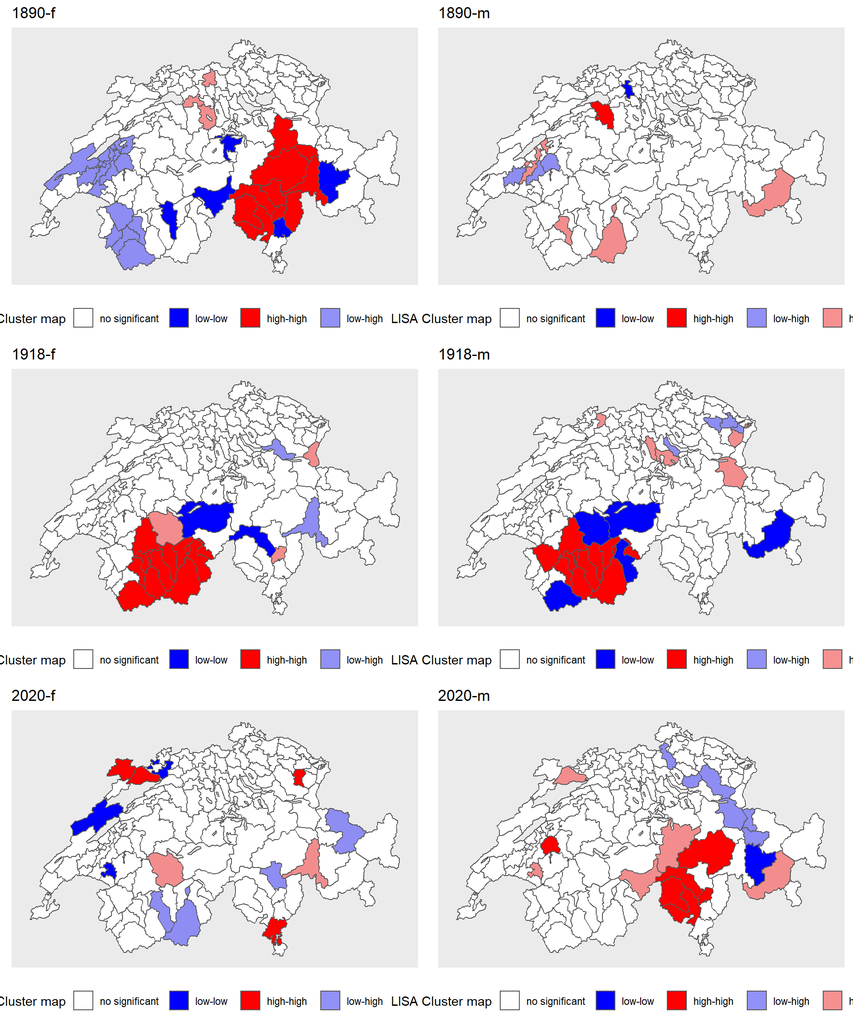

## Age

- Only two age groups 0-69 and >=70.
- More precise age groups would lead to a lot of zeros in small districts
- Even with two age groups, zeros in some districts

### Maps

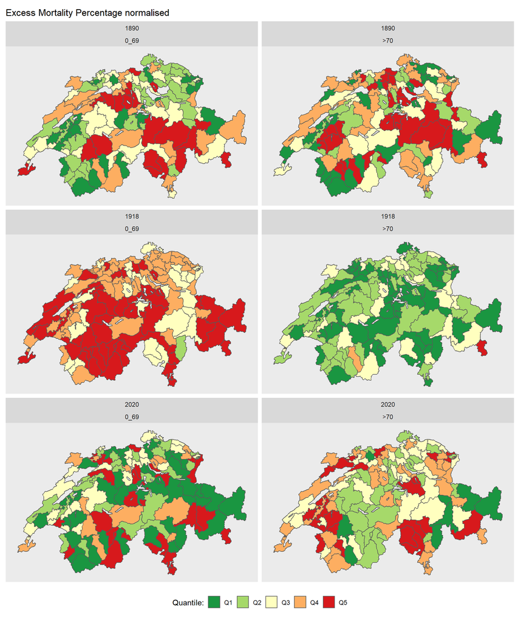

### LISA (Local Indicators of Spatial Association)

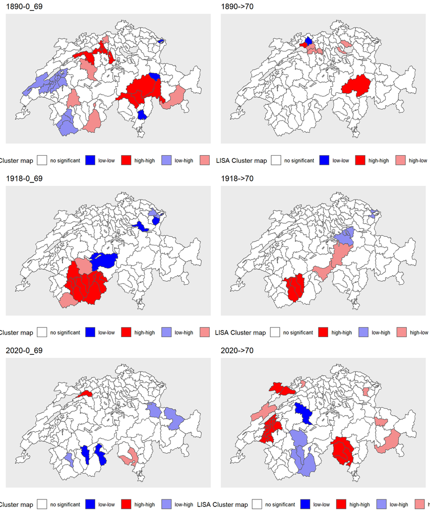

# Next steps, Points to be discussed

1. Bayesian approaches in hierarchical modelling (INLA)
- Lot of zeros, especially for age groups
- Bayesian approaches in hierarchical modelling (INLA) to investigate the spatial pattern of excess mortality per district
2. Groups
- Too many age groups lead to too many zeros -> too many zeros are also a problem with INLA
- Maybe only 0-69 and >70 or 0-40, 41-69, >70
- It is not possible to stratify by age and gender -> too many zeros
- We can estimate excess mortality for age groups and sex, but not by age groups for each sex
2. Further Co-factors (I have to discuss with Kaspar):
- Urbanization
- Infant mortality rates as a proxy for health index
- Public health intervention for each district (canton)
- GDP per capita as proxy for SES
- Population density (population/km2)
- Proportion of children, 5–15 y (as school-age children are thought to drive influenza transmission)